# Raise and fall of programming languages

Stackoverflow takes every year a survey from the users to different questions. I'll first take the data from latest 2019 survey to find answer on the following questions:

1) What are the languages with most change worked with this year and desired next year?

2) Are there differences in countries?

and with the survey data of 2018

3) Is the raise or fall of a language also seen in survey a year ago?

4) How good is the value `LanguageDesireNextYear` in comparison to the real value `LanguageWorkedWith` from next year?

```python
# read all relevant libraries and data
import numpy as np
import pandas as pd
import matplotlib.pyplot as plt
import seaborn as sns
%matplotlib inline
from wordcloud import WordCloud, STOPWORDS, ImageColorGenerator

#read the data
year = "2019"
df = pd.read_csv(year+'/survey_results_public.csv')
schema = pd.read_csv(year+'/survey_results_schema.csv')
```

### Data analysis

Print some basic data infos, like head, describe to get a feeling of the data.

```python
df.head()
```

|  | Respondent | MainBranch | Hobbyist | OpenSourcer | OpenSource | Employment | Country | Student | EdLevel | UndergradMajor | ... | WelcomeChange | SONewContent | Age | Gender | Trans | Sexuality | Ethnicity | Dependents | SurveyLength | SurveyEase |
| --- | --- | --- | --- | --- | --- | --- | --- | --- | --- | --- | --- | --- | --- | --- | --- | --- | --- | --- | --- | --- | --- |
| 0 | 1 | I am a student who is learning to code | Yes | Never | The quality of OSS and closed source software ... | Not employed, and not looking for work | United Kingdom | No | Primary/elementary school | NaN | ... | Just as welcome now as I felt last year | Tech articles written by other developers;Indu... | 14.0 | Man | No | Straight / Heterosexual | NaN | No | Appropriate in length | Neither easy nor difficult |
| 1 | 2 | I am a student who is learning to code | No | Less than once per year | The quality of OSS and closed source software ... | Not employed, but looking for work | Bosnia and Herzegovina | Yes, full-time | Secondary school (e.g. American high school, G... | NaN | ... | Just as welcome now as I felt last year | Tech articles written by other developers;Indu... | 19.0 | Man | No | Straight / Heterosexual | NaN | No | Appropriate in length | Neither easy nor difficult |
| 2 | 3 | I am not primarily a developer, but I write co... | Yes | Never | The quality of OSS and closed source software ... | Employed full-time | Thailand | No | Bachelor’s degree (BA, BS, B.Eng., etc.) | Web development or web design | ... | Just as welcome now as I felt last year | Tech meetups or events in your area;Courses on... | 28.0 | Man | No | Straight / Heterosexual | NaN | Yes | Appropriate in length | Neither easy nor difficult |
| 3 | 4 | I am a developer by profession | No | Never | The quality of OSS and closed source software ... | Employed full-time | United States | No | Bachelor’s degree (BA, BS, B.Eng., etc.) | Computer science, computer engineering, or sof... | ... | Just as welcome now as I felt last year | Tech articles written by other developers;Indu... | 22.0 | Man | No | Straight / Heterosexual | White or of European descent | No | Appropriate in length | Easy |
| 4 | 5 | I am a developer by profession | Yes | Once a month or more often | OSS is, on average, of HIGHER quality than pro... | Employed full-time | Ukraine | No | Bachelor’s degree (BA, BS, B.Eng., etc.) | Computer science, computer engineering, or sof... | ... | Just as welcome now as I felt last year | Tech meetups or events in your area;Courses on... | 30.0 | Man | No | Straight / Heterosexual | White or of European descent;Multiracial | No | Appropriate in length | Easy |

5 rows × 85 columns

```python
df.describe()
```

|  | Respondent | CompTotal | ConvertedComp | WorkWeekHrs | CodeRevHrs | Age |
| --- | --- | --- | --- | --- | --- | --- |
| count | 88883.000000 | 5.594500e+04 | 5.582300e+04 | 64503.000000 | 49790.000000 | 79210.000000 |
| mean | 44442.000000 | 5.519014e+11 | 1.271107e+05 | 42.127197 | 5.084308 | 30.336699 |
| std | 25658.456325 | 7.331926e+13 | 2.841523e+05 | 37.287610 | 5.513931 | 9.178390 |
| min | 1.000000 | 0.000000e+00 | 0.000000e+00 | 1.000000 | 0.000000 | 1.000000 |
| 25% | 22221.500000 | 2.000000e+04 | 2.577750e+04 | 40.000000 | 2.000000 | 24.000000 |
| 50% | 44442.000000 | 6.200000e+04 | 5.728700e+04 | 40.000000 | 4.000000 | 29.000000 |
| 75% | 66662.500000 | 1.200000e+05 | 1.000000e+05 | 44.750000 | 6.000000 | 35.000000 |
| max | 88883.000000 | 1.000000e+16 | 2.000000e+06 | 4850.000000 | 99.000000 | 99.000000 |

### Strange data

Out of this description of the few float/int columns you can see, that not all of the answers are useful. For example Age of 99 as programmer is possible, but Age of 1? Or the WorkWeekHrs: 4850 as max! One week has only 7x24 = 168 h maximun. So if we want to use this columns, you have to drop the strange data.

```python
df.info()
```

```
<class 'pandas.core.frame.DataFrame'>
RangeIndex: 88883 entries, 0 to 88882
Data columns (total 85 columns):
Respondent                88883 non-null int64
MainBranch                88331 non-null object
Hobbyist                  88883 non-null object
OpenSourcer               88883 non-null object
OpenSource                86842 non-null object
Employment                87181 non-null object
Country                   88751 non-null object
Student                   87014 non-null object
EdLevel                   86390 non-null object
UndergradMajor            75614 non-null object
EduOther                  84260 non-null object
OrgSize                   71791 non-null object
DevType                   81335 non-null object
YearsCode                 87938 non-null object
Age1stCode                87634 non-null object
YearsCodePro              74331 non-null object
CareerSat                 72847 non-null object
JobSat                    70988 non-null object
MgrIdiot                  61159 non-null object
MgrMoney                  61157 non-null object
MgrWant                   61232 non-null object
JobSeek                   80555 non-null object
LastHireDate              79854 non-null object
LastInt                   67155 non-null object
FizzBuzz                  71344 non-null object
JobFactors                79371 non-null object
ResumeUpdate              77877 non-null object
CurrencySymbol            71392 non-null object
CurrencyDesc              71392 non-null object
CompTotal                 55945 non-null float64
CompFreq                  63268 non-null object
ConvertedComp             55823 non-null float64
WorkWeekHrs               64503 non-null float64
WorkPlan                  68914 non-null object
WorkChallenge             68141 non-null object
WorkRemote                70284 non-null object
WorkLoc                   70055 non-null object
```

[output cut: 35 more lines]

```
SOJobs                    88066 non-null object
EntTeams                  87841 non-null object
SOComm                    88131 non-null object
WelcomeChange             85855 non-null object
SONewContent              69560 non-null object
Age                       79210 non-null float64
Gender                    85406 non-null object
Trans                     83607 non-null object
Sexuality                 76147 non-null object
Ethnicity                 76668 non-null object
Dependents                83059 non-null object
SurveyLength              86984 non-null object
SurveyEase                87081 non-null object
dtypes: float64(5), int64(1), object(79)
memory usage: 57.6+ MB
```

### Data cleaning

Many of the columns have missing values and most of the columns have type 'object'. If i would use the data for a model I've to look into it, but for now i'll concentrate on the necessary columns.

Lets first drop all empty rows and columns that exist in the dataset.

```python
# first drop all empty rows and columns, with method 'all'
df.dropna(how='all', inplace=True)
df.dropna(how='all', axis=1, inplace=True)
```

```python
# we want to have a look at the Language columns and country, so we drop the NA values there and method 'any'.
df.dropna(subset=['LanguageWorkedWith', 'LanguageDesireNextYear', 'Country'], inplace=True)
df.shape
```

```
(83460, 85)
```

### Generate a wordcloud for first overview

As a first look on the languages i will generate a wordcloud from all languages worked with and another one for languages desired for next year. I've to use an own regex, wordcloud uses `r"\w[\w']+"` but here we have languages like *C#* or *HTML/CSS*. So i will use `r"[A-Za-z#/]+"`.

```python
def plot_wordcloud(language, title=None):
    # all languages that one use, is in text string seperated with columns. So first generate one string, with all entries
    text = ";".join(text for text in language)
    #generate wordcloud with no collocations and with an own regex to handle e.g. C# and HTML/CSS
    wordcloud = WordCloud(collocations=False, width=2000, height=1000, max_words=1000, regexp= r"[A-Za-z#/]+",
                          background_color="white", relative_scaling=0).generate(text)
    plt.figure(figsize=(20,10))

    plt.imshow(wordcloud, interpolation="bilinear")
    plt.axis("off")

    if title != None:
        plt.figtext(0.5,1, title, ha='center',
                fontdict={'fontsize':30, 'color':  'darkred', 'fontweight':'bold'})
    plt.show()
    return wordcloud
    #wordcloud.to_file('languages_worked_with.png');
```

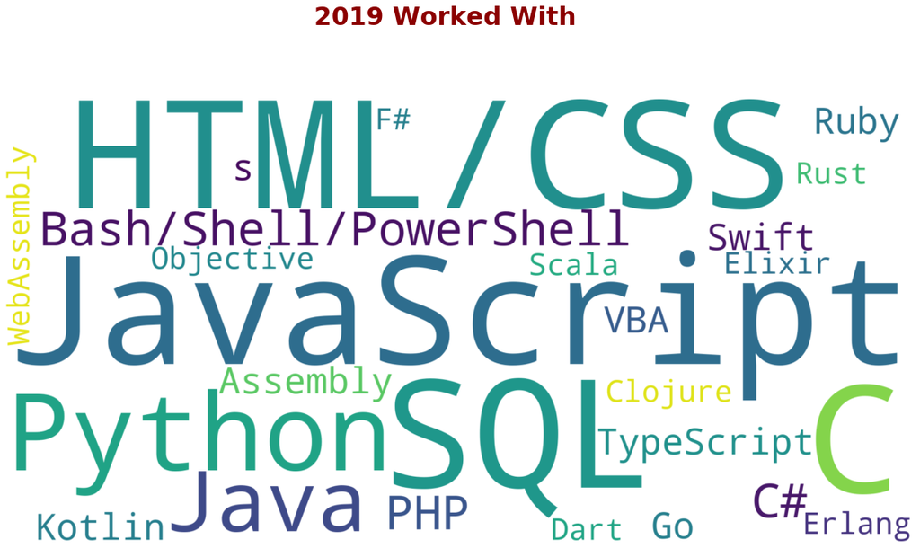

```python
language_worked_with = plot_wordcloud(df.LanguageWorkedWith, '2019 Worked With')
# save wordcloud for later use in blog
language_worked_with.to_file('languages_worked_with.png');
```

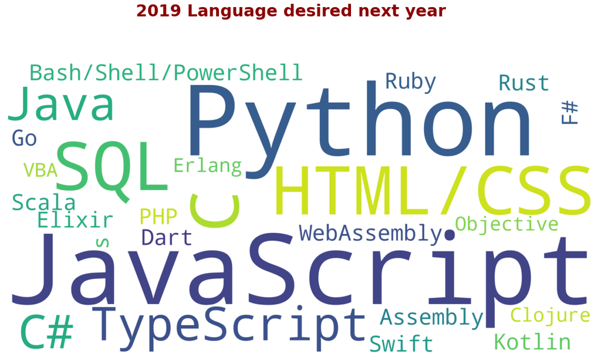

```python
language_desire_nyear = plot_wordcloud(df.LanguageDesireNextYear, '2019 Language desired next year')

language_desire_nyear.to_file('language_desire_next_year.png');
```

### First look at the wordcloud

From the first view it seems, that most of the big languages in the next year are decreasing, like Java, JavaScipt and C.

And we have also increasing candidates: Rust and Python. Let's have a closer look through data visualization.

```python
def language_percent(df, language):
    """
    Function to calculate the percent language used
    Input: dataframe, language
    Output: dataframe with language, workedWith(percent), desiredNextYear(percent)
    """
    count_respondent = df.Respondent.count()
    #need to use regexp, because of
    language_raw = r'\b{}\b'.format(language)
    language_perc = pd.DataFrame(columns=['language', 'workedWith', 'desiredNextYear'])

    workedWith = df[df.LanguageWorkedWith.str.contains(language_raw, regex=True)].Respondent.count() / count_respondent
    desiredNextYear = df[df.LanguageDesireNextYear.str.contains(language_raw, regex=True)].Respondent.count() / count_respondent
    language_perc = language_perc.append(pd.DataFrame(np.array([[language, workedWith, desiredNextYear]]), columns=['language', 'workedWith', 'desiredNextYear']))

    return language_perc
```

```python
def plot_languages(df, country=None):
    """
    Plots a bar chart with the languages used this year, desired for next year and the difference
    could be filtered to a special country
    """
    if country is not None:
        data = df[df.Country == country]
    else:
        data = df

    ret = language_percent(data, 'Python')
    ret = ret.append(language_percent(data, 'C'), ignore_index=True)
    ret = ret.append(language_percent(data, 'Java'), ignore_index=True)
    ret = ret.append(language_percent(data, 'JavaScript'), ignore_index=True)
    ret = ret.append(language_percent(data, 'Rust'), ignore_index=True)

    ret= ret.set_index('language')
    # have to set astype to float64, otherwise plot raises an error
    ret = ret.astype({'workedWith':'float64', 'desiredNextYear':'float64'})
    # calculate the difference
    ret['diff'] = ret.desiredNextYear - ret.workedWith
    #ax.axhline(y=0, linewidth=0.5)

    ret.plot(kind='bar', use_index=True);
    if country is not None:
        plt.title(country)

    plt.axhline(y=0, linewidth=0.5);
    return ret
```

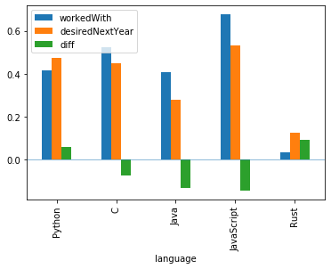

```python
lang_percent_2019 = plot_languages(df)
```

[output not shown]

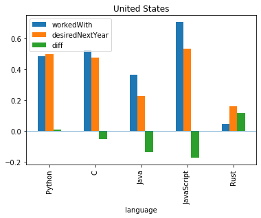

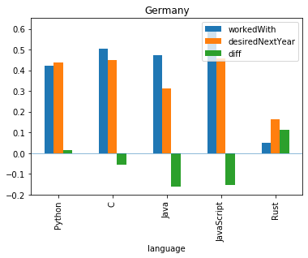

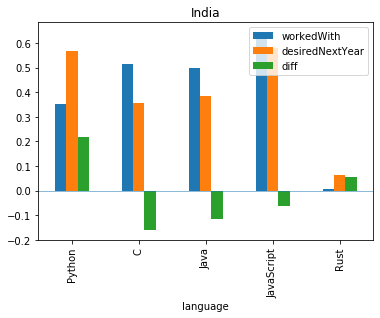

```python
plot_languages(df, 'United States')
plot_languages(df, 'Germany')
plot_languages(df, 'India')
```

### Python and Rust are increasing

Now we have proved our findings, the languages Java, Javascript and C are on the decreasing side of to be used in the future. Whereas Python and Rust are increasing, so more people wants to work with them in the next year. Interesting is in the United States and Germany, Python is increasing only a little bit, but in India there are around 20% increase for the next year. And Rust as language is in all mentioned countries increasing. Also interesting, that in India more people wants to drop C as language and in United States and Germany more people drop Java and JavaScript.

## Let's see how it was a year ago

Therefore i load the data from 2018 and have a look only at the desired fields `['Respondent','LanguageWorkedWith', 'LanguageDesireNextYear', 'Country']`

```python
year = "2018"
df_18 = pd.read_csv(year+'/survey_results_public.csv', usecols=['Respondent','LanguageWorkedWith', 'LanguageDesireNextYear', 'Country'],
                    dtype={'LanguageWorkedWith':'str', 'LanguageDesireNextYear':'str', 'Country':'str'})
```

```python
# first drop all empty rows, i don't have to drop empty columns, because i loaded only special columns which are not empty
df_18.dropna(how='all', inplace=True)

df_18.dropna(subset=['LanguageWorkedWith', 'LanguageDesireNextYear', 'Country'], inplace=True)
df_18.dtypes
```

```
Respondent                 int64
Country                   object
LanguageWorkedWith        object
LanguageDesireNextYear    object
dtype: object
```

```python
df_18.LanguageWorkedWith.unique()
```

```
array(['JavaScript;Python;HTML;CSS', 'JavaScript;Python;Bash/Shell',
       'C#;JavaScript;SQL;TypeScript;HTML;CSS;Bash/Shell', ...,
       'JavaScript;Lua;Bash/Shell',
       'PHP;Python;Ruby;SQL;Visual Basic 6;HTML;CSS;Bash/Shell',
       'PHP;SQL;Visual Basic 6;Delphi/Object Pascal;HTML;CSS'],
      dtype=object)
```

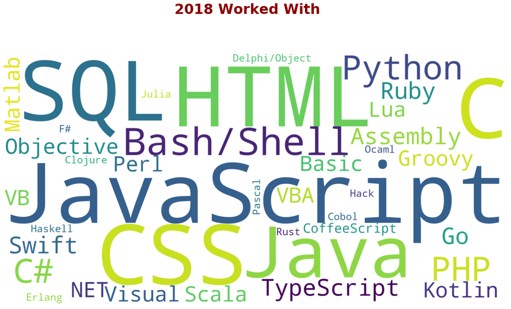

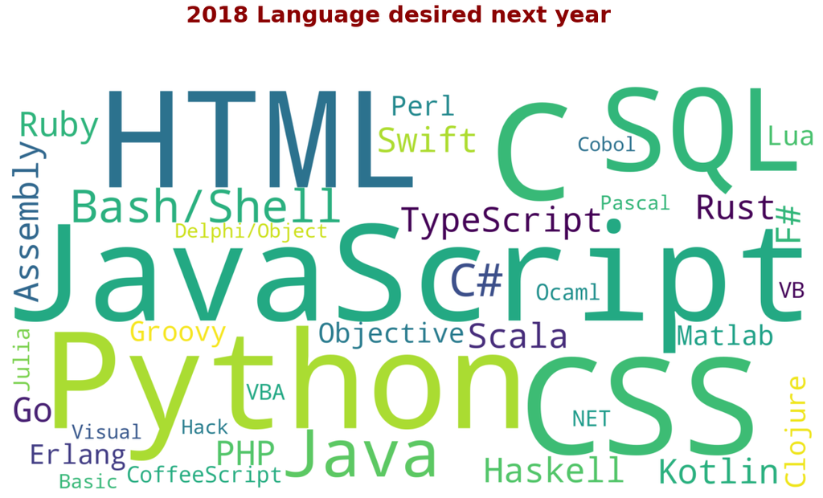

```python
language_worked_with18 = plot_wordcloud(df_18.LanguageWorkedWith, '2018 Worked With')
language_desire_nyear18 = plot_wordcloud(df_18.LanguageDesireNextYear, '2018 Language desired next year')
```

```python
language_worked_with18.to_file('language_worked_with18.png')
language_desire_nyear18.to_file('language_desire_nyear18.png')
```

```
<wordcloud.wordcloud.WordCloud at 0x1651cb88e48>
```

### Findings

One obvious finding from the word cloud is, that many more languages are mentioned in 2018, not more mentioned in 2019! E.g. Cobol and Pascal. But as the languages were predefined in the survey from StackOverFlow, you cannot conlcude, that one of these languages are not more used.

The raise of python is here only in india and rust is raising in all three countries as you can see on the following plots. But in comparison to 2019, the desired languages are not raise or fall as fast as mentioned.

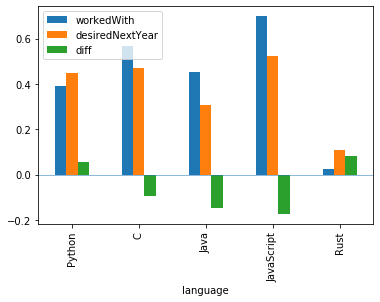

```python
lang_percent_2018 = plot_languages(df_18)
```

[output not shown]

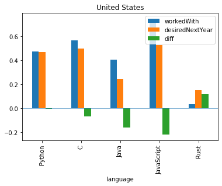

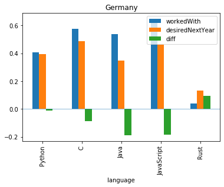

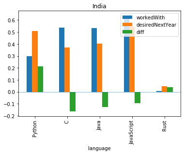

```python
plot_languages(df_18, 'United States')
plot_languages(df_18, 'Germany')
plot_languages(df_18, 'India')
```

```python
lang_percent_2019 = lang_percent_2019.rename(
    columns={'workedWith':'workedWith2019', 'desiredNextYear':'desiredNextYear2019', 'diff':'diff2019'})
```

```python
lang_percent = pd.merge(lang_percent_2018, lang_percent_2019, how='left', on='language')
lang_percent.drop('diff', axis=1, inplace=True)
lang_percent.drop('diff2019', axis=1, inplace=True)
```

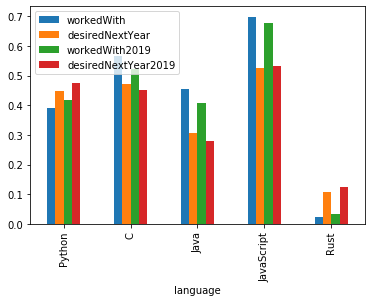

```python
lang_percent.plot(kind='bar')
```

As expected, the wish to work or not to work with a language next year is bigger than the real world. If you see JavaScript for example, nearly 20 % wantet to don't use in the next year, but in 2019 there is only a few percent decrease in programmers, that are worked with JavaScript.

## Conclusion

The languages used for programming in the last two years are changing. In 2018 many more languages were mentioned as in 2019, but that is coming from the survey creators. The top used languages like C, Java and Javascript are still used and not so fast decreasing as many developers desired. Especially if you compare 2018 and 2019. Another interesting finding, ist that in India most people don't want to use C in the next year, in 2018 and also in 2019. Therefore they want to use Python or Rust. Whereas in Germany and United States the developers don't want to use Java and JavaScript and Python is raising from 2019 on and not in 2018.